# HOW CAN A WELLNESS COMPANY CAN PLAY IT SMART

### HEARTRATE

- 14 participants

```r
heart<- read.csv("C://Users//ACER//Downloads//heartrate_seconds_merged.csv (1)//heartrate_seconds_merged.csv")
```

```r
unique(heart$Id)
```

```
##  [1] 2022484408 2026352035 2347167796 4020332650 4388161847 4558609924
##  [7] 5553957443 5577150313 6117666160 6775888955 6962181067 7007744171
## [13] 8792009665 8877689391
```

- Recorded every seconds. Making it impossible to combine with other datasets which are in minutes. Below is a chart of each individual heart beat rate distribution.

```r
heart$Id  = factor(heart$Id)
```

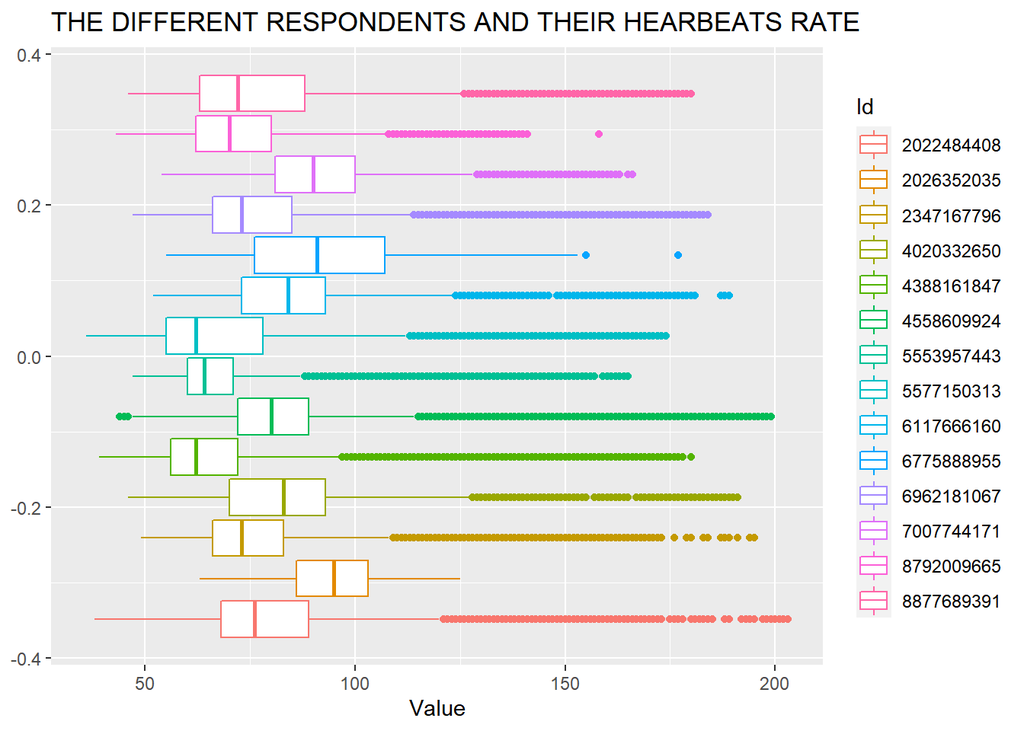

```r
heart %>%
  ggplot(aes(Value, color = Id))+
  geom_boxplot()+
  labs(title = "THE DIFFERENT RESPONDENTS AND THEIR HEARBEATS RATE")
```

- 33 respondents

```r
mets <- read.csv("C://Users//ACER//Downloads//minuteMETsNarrow_merged.csv//minuteMETsNarrow_merged.csv")
```

```r
unique(mets$Id)
```

```
##  [1] 1503960366 1624580081 1644430081 1844505072 1927972279 2022484408
##  [7] 2026352035 2320127002 2347167796 2873212765 3372868164 3977333714
## [13] 4020332650 4057192912 4319703577 4388161847 4445114986 4558609924
## [19] 4702921684 5553957443 5577150313 6117666160 6290855005 6775888955
## [25] 6962181067 7007744171 7086361926 8053475328 8253242879 8378563200
## [31] 8583815059 8792009665 8877689391
```

- Below is the summary of the dataset

```r
summary(mets$Id)
```

```
##      Min.   1st Qu.    Median      Mean   3rd Qu.      Max.
## 1.504e+09 2.320e+09 4.445e+09 4.848e+09 6.962e+09 8.878e+09
```

- Below is a distribution of the METs values. It shows a largely sedentary lifestyle with few exceptions exerting more than average energy expenditure and engaging in rigorous activities.

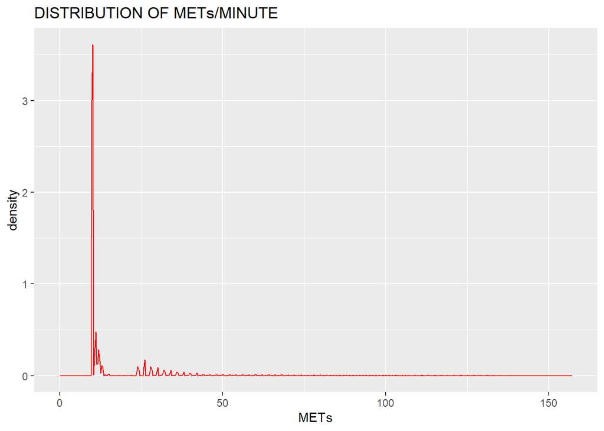

```r
mets %>%
  ggplot(aes(METs))+
  geom_density(color = "red")+
  labs(title = "DISTRIBUTION OF METs/MINUTE")
```

## BELLABEAT LEAF

- Wristband, brooch or a necklace Fitness tracker

### STRENGHTS

*Aesthetically attractive. Looks like a piece of Jewelry

- Uniquely positioned for women
- Tracks activities, sleep, steps, stress, reproductive health
- long battery life (six months). no need to keep recharging weekly
- Medium price
- for sale online from company website and some major online stores

### WEAKNESSES

- Positioned mainly for women
- Limited application tracking
- Need to change position of leaf for monitoring different activities
- Not available in physical stores.

## CONCLUSION/RECOMMENDATION

- The fitness trackers market is highly dynamic and constantly changing as new devices are released, relaunching of existing brands, withdrawal of non performing brands, new vendors entering or leaving or acquired by bigger vendors.How do you explain FITBIT going from biggest market share holder in 2016 to insignificant share today.
- The market is innovation technology driven.
- This dataset showed how consumers use their trackers and the different applications used at that time 2016-2017. Many Consumers dont use their trackers everyday.
- BellaBeat trackers don’t track enough applications compared to FITBIT at the this assumed epoch 2016-2017. BellaBeat needs to increase applications of their trackers to include for instance heart beat rate, calories burnt, glucose etc and be more proactive.
- BellaBeats need to increase application types including heartbeat, glucose etc.
- Why limit BellaBeat products to women only. Why not men or unisex products as well. Limiting products to women only reduces target audience, product purchase and shares by almost half.
- if 60% consumers purchase trackers online, there is a need to increase online presence especially advertisement. There is need to sell in physical stores to cater for 40% of target audience that buy offline.
- North America controls almost half of buyers followed by Europe. However, Asia seems to be an emerging market with great potentials for growth due to their large population. Distribution plus advertisement of BellaBeat products in these areas should be emphasized.
- Finaly, there is need for further research to compare performance of BellaBeat Products with key brands.It will also serve as a feedback from consumers on evaluation of the BellaBeat products, their strengths as well as areas of improvement.